# Data Science Assignment 04

Author

Gustavo Murillo and Sean Conner

```r
# load packages
library(tidyverse)
library(dplyr)
library(readr)
library(purrr)
library(janitor)
library(urbnthemes)
library(remotes)
library(scales)
library(ggrepel)

set_urbn_defaults(style = "print")
```

# Data Download

```r
# download EPI 2022 raw data into data folder in the working directory
download.file(
  url = "https://epi.yale.edu/downloads/epi2022rawdata.zip",
  destfile = "data/epi_2022.zip"
)

# unzip file into data folder in the working directory
unzip(
  zipfile = "data/epi_2022.zip",
  exdir = "data")

# load emissions data
raw_ghg <- read_csv("data/2022 EPI Raw Data/GHG_raw.csv") %>%
  # select years 2001 to 2019
  select(country,
         GHG.raw.2001, GHG.raw.2002, GHG.raw.2003,
         GHG.raw.2004, GHG.raw.2005, GHG.raw.2006,
         GHG.raw.2007, GHG.raw.2008, GHG.raw.2009,
         GHG.raw.2010, GHG.raw.2011, GHG.raw.2012,
         GHG.raw.2013, GHG.raw.2014, GHG.raw.2015,
         GHG.raw.2016, GHG.raw.2017, GHG.raw.2018,
         GHG.raw.2019)

# load economic data
raw_gdp <- read_csv("data/2022 EPI Raw Data/GDP_raw.csv") %>%
  # select years 2001 to 2019
  select(country,
         GDP.raw.2001, GDP.raw.2002, GDP.raw.2003,
         GDP.raw.2004, GDP.raw.2005, GDP.raw.2006,
         GDP.raw.2007, GDP.raw.2008, GDP.raw.2009,
         GDP.raw.2010, GDP.raw.2011, GDP.raw.2012,
         GDP.raw.2013, GDP.raw.2014, GDP.raw.2015,
         GDP.raw.2016, GDP.raw.2017, GDP.raw.2018,
         GDP.raw.2019)

# load population data
raw_pop <- read_csv("data/2022 EPI Raw Data/POP_raw.csv") %>%
  # select years 2001 to 2019
  select(country,
         POP.raw.2001, POP.raw.2002, POP.raw.2003,
         POP.raw.2004, POP.raw.2005, POP.raw.2006,
         POP.raw.2007, POP.raw.2008, POP.raw.2009,
         POP.raw.2010, POP.raw.2011, POP.raw.2012,
         POP.raw.2013, POP.raw.2014, POP.raw.2015,
         POP.raw.2016, POP.raw.2017, POP.raw.2018,
         POP.raw.2019)
```

# Data Processing and Manipulation

```r
fin_ghg <- raw_ghg %>%
  # pivot table wide to long
  pivot_longer(cols = c("GHG.raw.2001", "GHG.raw.2002",
                        "GHG.raw.2003", "GHG.raw.2004",
                        "GHG.raw.2005", "GHG.raw.2006",
                        "GHG.raw.2007", "GHG.raw.2008",
                        "GHG.raw.2009", "GHG.raw.2010",
                        "GHG.raw.2011", "GHG.raw.2012",
                        "GHG.raw.2013", "GHG.raw.2014",
                        "GHG.raw.2015", "GHG.raw.2016",
                        "GHG.raw.2017", "GHG.raw.2018",
                        "GHG.raw.2019"),
               names_to = "year",
               values_to = "emissions") %>%
  ## change values in year column
  mutate(
    year = str_replace(year, "GHG.raw.", "")
  )

fin_gdp <- raw_gdp %>%
  # pivot table wide to long
  pivot_longer(cols = c("GDP.raw.2001", "GDP.raw.2002",
                        "GDP.raw.2003", "GDP.raw.2004",
                        "GDP.raw.2005", "GDP.raw.2006",
                        "GDP.raw.2007", "GDP.raw.2008",
                        "GDP.raw.2009", "GDP.raw.2010",
                        "GDP.raw.2011", "GDP.raw.2012",
                        "GDP.raw.2013", "GDP.raw.2014",
                        "GDP.raw.2015", "GDP.raw.2016",
                        "GDP.raw.2017", "GDP.raw.2018",
                        "GDP.raw.2019"),
               names_to = "year",
               values_to = "GDP") %>%
  ## change values in year column
  mutate(
    year = str_replace(year, "GDP.raw.", "")
  )

fin_pop <- raw_pop %>%
  # pivot table wide to long
  pivot_longer(cols = c("POP.raw.2001", "POP.raw.2002",
                        "POP.raw.2003", "POP.raw.2004",
                        "POP.raw.2005", "POP.raw.2006",
                        "POP.raw.2007", "POP.raw.2008",
                        "POP.raw.2009", "POP.raw.2010",
                        "POP.raw.2011", "POP.raw.2012",
                        "POP.raw.2013", "POP.raw.2014",
                        "POP.raw.2015", "POP.raw.2016",
                        "POP.raw.2017", "POP.raw.2018",
                        "POP.raw.2019"),
               names_to = "year",
               values_to = "population") %>%
  ## change values in year column
  mutate(
    year = str_replace(year, "POP.raw.", "")
  )

# join emissions and GDP tables
ghg_gdp <- left_join(fin_ghg,
                     fin_gdp,
                     by = c("country" = "country", "year" = "year"))

# join ghg_gdp with population table
ghg_gdp_pop <- left_join(ghg_gdp,
                         fin_pop,
                         by = c("country" = "country", "year" = "year")) %>%
  filter(emissions > 0 & GDP > 0 & population > 0)

# print final, cleaned table
ghg_gdp_pop
```

```
# A tibble: 3,633 × 5
   country     year  emissions          GDP population
   <chr>       <chr>     <dbl>        <dbl>      <dbl>
 1 Afghanistan 2002     16674. 26890054382.   22600774
 2 Afghanistan 2003     17359. 29265058689.   23680871
 3 Afghanistan 2004     17113. 29678901146.   24726689
 4 Afghanistan 2005     18023. 33011757108.   25654274
 5 Afghanistan 2006     18472. 34780330056.   26433058
 6 Afghanistan 2007     19400. 39589169630.   27100542
 7 Afghanistan 2008     22875. 41143038133.   27722281
 8 Afghanistan 2009     26106. 49943751387.   28394806
 9 Afghanistan 2010     30099. 57116893447.   29185511
10 Afghanistan 2011     34584. 57360414055.   30117411
# … with 3,623 more rows
```

# Visualization: Emissions per Capita

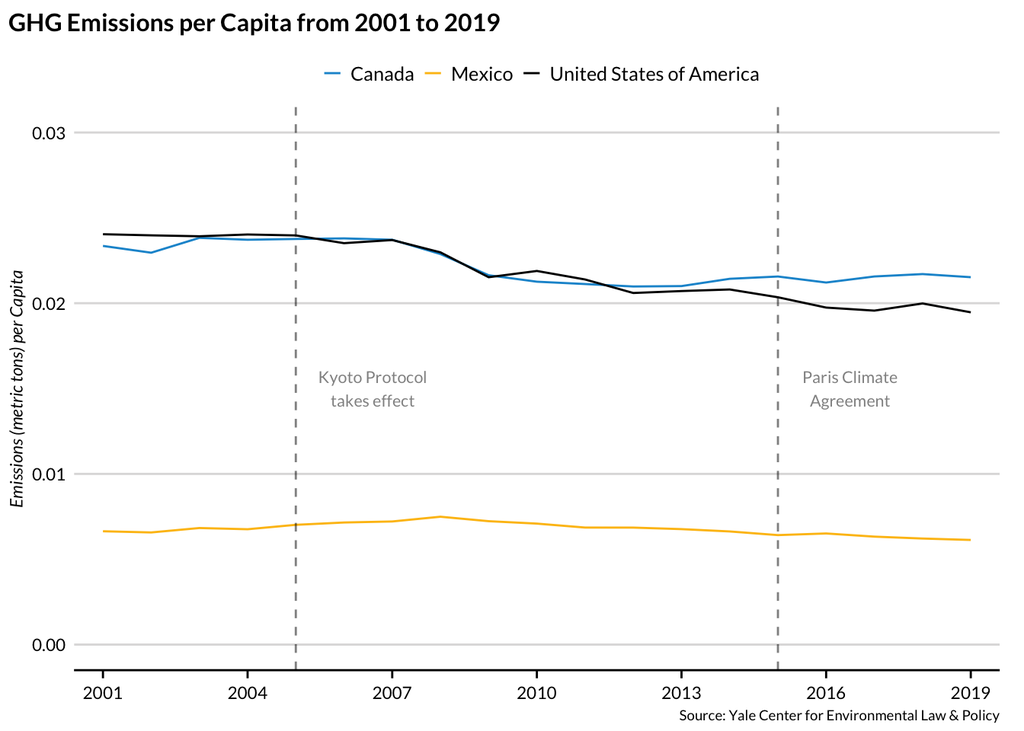

```r
# create new variable that measures emissions per unit of GDP
ghg_gdp_pop <- ghg_gdp_pop %>%
  mutate(emissions_per_capita = (emissions / population))

# visualize the new variable over time from 2005 to 2019
ghg_gdp_pop %>%
  filter(country %in% c("Canada",
                        "Mexico",
                        "United States of America")) %>%
  mutate(country = factor(country,
                          levels = c("Canada",
                                     "Mexico",
                                     "United States of America"))) %>%
  ggplot() +
  geom_line(aes(x = year, y = emissions_per_capita,
                group = country,
                color = country)) +
  geom_vline(xintercept = 15,
             linetype = "dashed",
             alpha = 0.5) +
  annotate("text", x = 16.5, y = 0.015,
           label = "Paris Climate\nAgreement",
           alpha = 0.5) +
  geom_vline(xintercept = 5,
             linetype = "dashed",
             alpha = 0.5) +
  annotate("text", x = 6.6, y = 0.015,
           label = "Kyoto Protocol\ntakes effect",
           alpha = 0.5) +
  labs(title = "GHG Emissions per Capita from 2001 to 2019",
       caption = "Source: Yale Center for Environmental Law & Policy",
       x = NULL,
       y = "Emissions (metric tons) per Capita") +
  scale_x_discrete(breaks = c("2001", "2004", "2007", "2010",
                              "2013", "2016", "2019")) +
  scale_y_continuous(limits = c(0, 0.03))
```

The Environmental Performance Index assigns a single value to every country’s state of environmental protection, resilience, and performance. This visualization uses data from the raw data files, supplied on the EPI website, for greenhouse gas emissions and population. Simply, it illustrates the change over time in emissions, measured in metric tons, per capita. Using the data manipulation techniques, written in the code above, we calculated emissions per capita as a new variable for every country in every year from 2001 to 2019 (most recent year of data provided by the EPI). We also highlight two key events for emissions reduction efforts in the 21st century: the Kyoto Protocol coming into effect in 2005 and the Paris Climate Agreement in 2015. There would be a lot more to unpack with additional data, as to the trajectory of these paths, the similarities and differences in the countries’ industrial makeups, and the apparent lack of emissions reductions for all three countries.

# Visualization: Cross-sectional, Global Emissions and GDP per Capita in 2019

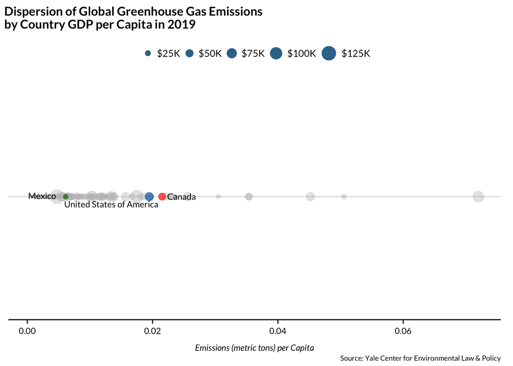

```r
ghg_gdp_pop <- ghg_gdp_pop %>%
  mutate(gdp_per_capita = (GDP / population))

ggplot() +
    geom_point(data = filter(ghg_gdp_pop,
                           year == 2019 &
                             (country != "Canada" &
                                country != "Mexico" &
                                country != "United States of America")),
             aes(x = emissions_per_capita, y = factor(1),
                 size = gdp_per_capita),
             alpha = 0.4,
             color = "gray") +
  geom_point(data = filter(ghg_gdp_pop,
                           year == 2019 &
                             country == "Canada"),
             aes(x = emissions_per_capita, y = factor(1),
                 size = gdp_per_capita),
             alpha = 0.8,
             color = "#f44336") +
  geom_point(data = filter(ghg_gdp_pop,
                           year == 2019 &
                             country == "Mexico"),
             aes(x = emissions_per_capita, y = factor(1),
                 size = gdp_per_capita),
             alpha = 0.8,
             color = "#38761d") +
  geom_point(data = filter(ghg_gdp_pop,
                           year == 2019 &
                             country == "United States of America"),
             aes(x = emissions_per_capita, y = factor(1),
                 size = gdp_per_capita),
             alpha = 0.8,
             color = "#2876b0") +
  geom_text_repel(data = filter(ghg_gdp_pop,
                          year == 2019 &
                            (country == "Canada" |
                               country == "Mexico" |
                               country == "United States of America")),
            aes(x = emissions_per_capita, y = factor(1),
                label = country),
            size = 3) +
  scale_radius(labels = scales::label_dollar(scale_cut = cut_long_scale())) +
  scale_y_discrete(labels = "") +
  labs(title = paste0("Dispersion of Global Greenhouse Gas Emissions\nby ",
                      "Country GDP per Capita in 2019"),
       x = "Emissions (metric tons) per Capita",
       y = NULL,
       caption = "Source: Yale Center for Environmental Law & Policy")
```

Building on the first visualization, this scale captures where each of the chosen countries fit in the global context of greenhouse gas emissions. Again, we use emissions per capita because absolute emissions counts vary so widely that the graph lacks interpretability. Also, emissions per capita help to standardize countries across all industrial and developmental contexts. This visualization adds context to the first graph, in a way, by zooming in on the 2019 data to show that Canada and the United States certainly outpace Mexico in emissions output but also they outpace many countries, even when accounting for population. We also add another layer of information by sizing the points by GDP per capita. While the relationship is not statistically clear from this graph, at a glance, we can see as emissions increase so does GDP, with a few exceptions. Ultimately, decoupling emissions from GDP will be necessary to fuel a clean energy transition, meaning countries need to understand this relationship and attempt to grow their economies with less emissions-intensive practices.

# Visualization: Longitudinal, Tracking the Relationship of Emissions and GDP from 2001 to 2019

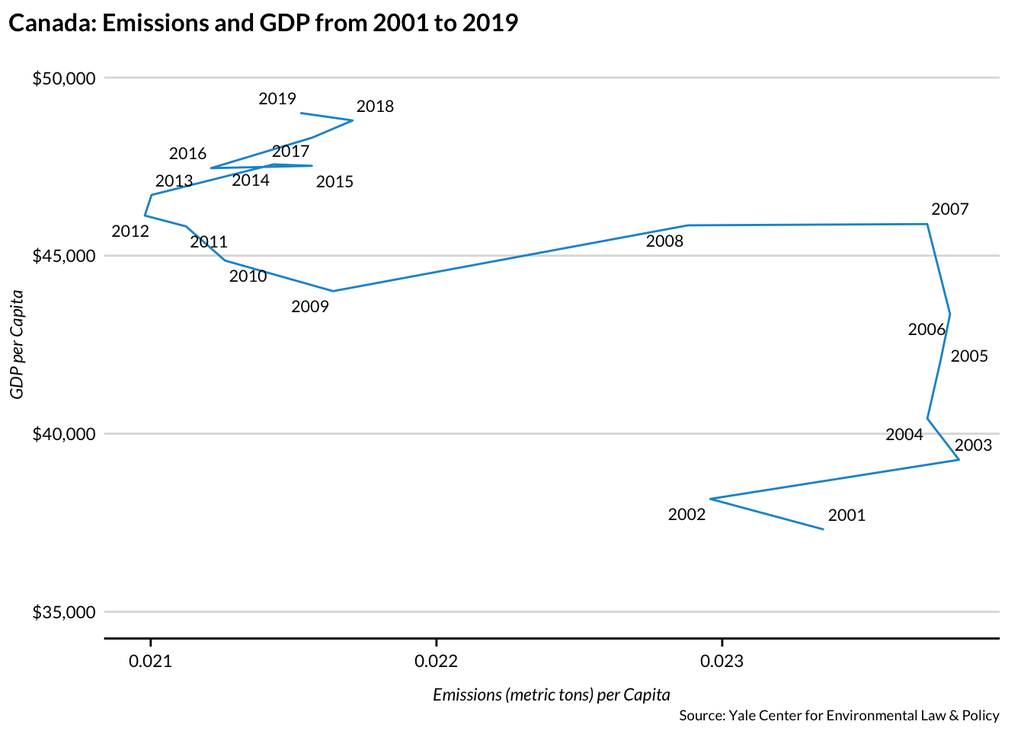

```r
c <- ghg_gdp_pop %>%
  filter(country %in% c("Canada")) %>%
  ggplot() +
  geom_path(mapping = aes(x = emissions_per_capita, y = gdp_per_capita,
                          group = country)) +
  geom_text_repel(mapping = aes(x = emissions_per_capita, y = gdp_per_capita,
                                label = year)) +
  labs(title = "Canada: Emissions and GDP from 2001 to 2019",
       x = "Emissions (metric tons) per Capita",
       y = "GDP per Capita",
       caption = "Source: Yale Center for Environmental Law & Policy") +
  scale_y_continuous(limits = c(35000, 50000),
                     labels = scales::dollar)

m <- ghg_gdp_pop %>%
  filter(country %in% c("Mexico")) %>%
  ggplot() +
  geom_path(mapping = aes(x = emissions_per_capita, y = gdp_per_capita,
                          group = country)) +
  geom_text_repel(mapping = aes(x = emissions_per_capita, y = gdp_per_capita,
                                label = year)) +
  labs(title = "Mexico: Emissions and GDP from 2001 to 2019",
       x = "Emissions (metric tons) per Capita",
       y = "GDP per Capita",
       caption = "Source: Yale Center for Environmental Law & Policy") +
  scale_y_continuous(limits = c(17000, 20000),
                      labels = scales::dollar)

us <- ghg_gdp_pop %>%
  filter(country %in% c("United States of America")) %>%
  ggplot() +
  geom_path(mapping = aes(x = emissions_per_capita, y = gdp_per_capita,
                          group = country)) +
  geom_text_repel(mapping = aes(x = emissions_per_capita, y = gdp_per_capita,
                                label = year)) +
  labs(title = "United States: Emissions and GDP from 2001 to 2019",
       x = "Emissions (metric tons) per Capita",
       y = "GDP per Capita",
       caption = "Source: Yale Center for Environmental Law & Policy") +
  scale_y_continuous(limits = c(50000, 65000),
                     labels = scales::dollar)

c
```

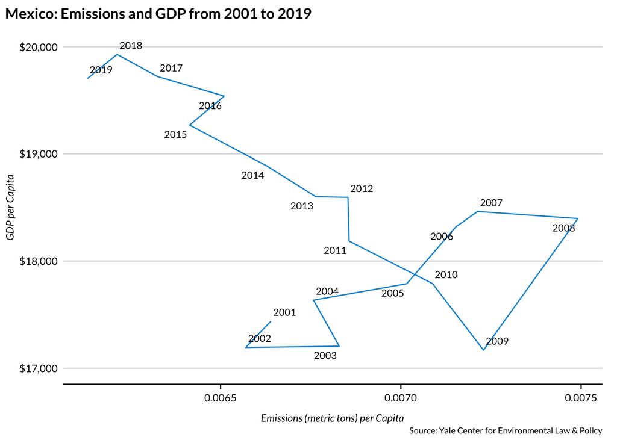

```r
m
```

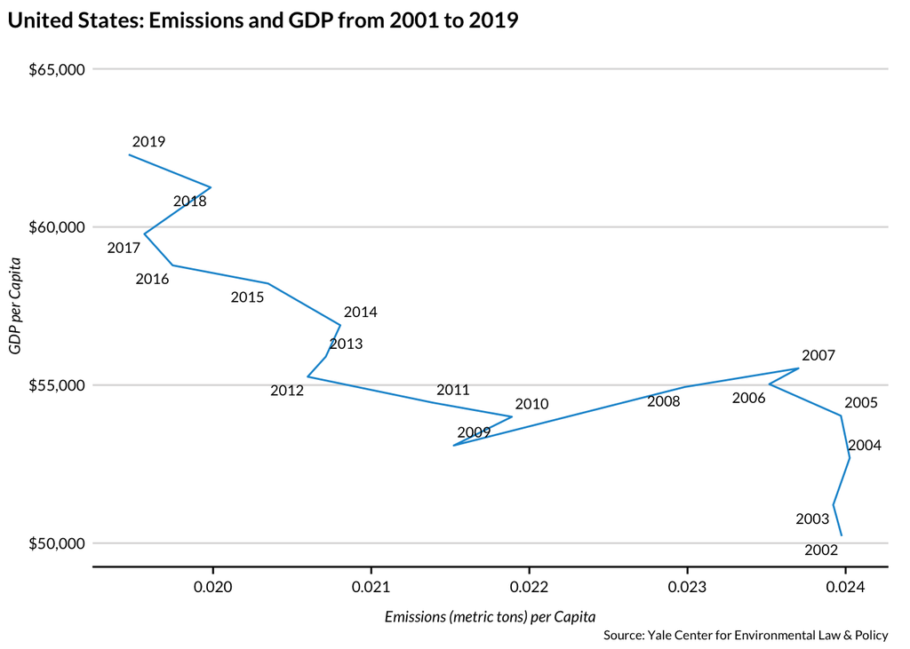

```r
us
```

This last set of visualizations focuses on the apparent relationship in the second graph between emissions and GDP. Each graph shows the emissions-GDP trajectory for one of the three chosen countries. It actually appears to counter the point made in the previous visualization, that over time as emissions per capita have decreased, GDP per capita has increased. We contend that there are other important factors driving GDP growth, and for already developed countries, the relationship may be more spurious than for developing countries. In all, we attempted to understand the data that goes into the EPI scores with this exploratory data analysis and to visualize some of the relationships and assumptions on which these scores are built.

# Visualization: Environmental Performance Index 2022

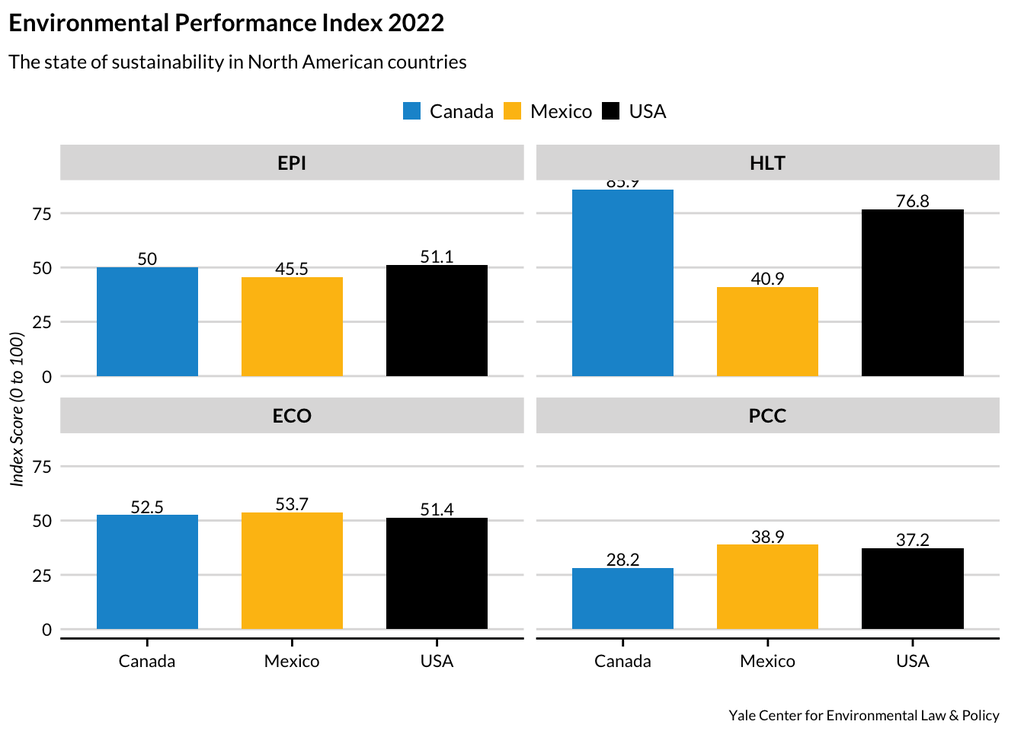

```r
EPI2022 <- read.csv('https://epi.yale.edu/downloads/epi2022results05302022.csv')

new_EPI2022 <- EPI2022 %>%
  filter(country== "Mexico" | country == "United States of America" | country == "Canada") %>%
  select("country", "EPI.new", "HLT.new", "ECO.new", "PCC.new")

## Changing the data
new_EPI2022 %>%
  pivot_longer(cols = -country, names_to = 'indices', values_to = 'values') %>%
  mutate(indices = str_remove(indices, pattern = '.new'), indices = factor(indices, levels = c("EPI", "HLT", "ECO", "PCC")),
         country = fct_recode(country, 'USA' = 'United States of America')) %>%
  ggplot(aes(x=country, y=values, fill=country)) +
  geom_bar(position="dodge", stat="identity") +
  geom_text(aes(label=values), vjust=-0.2, size=3)+
  facet_wrap(~indices) +
  labs(title = 'Environmental Performance Index 2022',
       subtitle = 'The state of sustainability in North American countries',
       x = '',
       y = 'Index Score (0 to 100)',
       caption = 'Yale Center for Environmental Law & Policy')
```

Canada, Mexico and the United States show a similar overall performance in the Environmental Performance Index 2022. However, some differences can be seen across the three policy objectives/ pillars measured within the index. While the three countries show no significant difference in the Ecosystem Vitality pillar, Mexico underperforms in the Environmental Health Pillar (HLT), which measures the quality of air, water, and exposure to heavy metals. In addition, although all countries show significant area of improvement within the Climate Change policy objective, Canada falls 10 points behind Mexico and the United States.

Source: [Yale Center for Environmental Law & Policy](https://epi.yale.edu)